# Audi

MV

6/8/2020

# Norgesbilparken

Carga de librerias:

```r
library(dplyr)
```

```r
library(tidyr)
library(ggplot2)
library(knitr)
library(kableExtra)
library(tidyverse)
library(raster)
library(sp)
library(rgdal)
```

## Data nedlasting:

01960: Registrerte kjøretøy, etter statistikkvariabel og år https://www.ssb.no/bilreg

```r
library(readr)
veh_matric_1950_2020 <- read_delim("C:/mio/Big/estudios_mv/veh_matric_1950_2020.csv",
    ";", escape_double = FALSE, locale = locale(encoding = "ISO-8859-1"),
    trim_ws = TRUE)
View(veh_matric_1950_2020)
```

## Norsk kjøretøyregistrering grafen (1950-2020)

```r
registreret <- veh_matric_1950_2020
registreret$vehic <- as.numeric(registreret$vehic)
registreret %>% filter (Typer == "Kjøretøy i alt") %>%
  dplyr::select(år,vehic)%>%
  slice(seq(1,80,10),66:70)%>%
  spread(år, vehic)%>% #transponer la tabla
  kable() %>%
  kable_styling(full_width = F, position = "center", font_size = 10) %>%
  row_spec(row = 0, background="green", bold=T, color="white")
```

| 1950 | 1960 | 1970 | 1980 | 1990 | 2000 | 2010 | 2015 | 2016 | 2017 | 2018 | 2019 |
| --- | --- | --- | --- | --- | --- | --- | --- | --- | --- | --- | --- |
| 150579 | 542312 | 1188973 | 2025944 | 2930277 | 3484593 | 4604846 | 5214039 | 5335076 | 5444740 | 5515360 | 5623196 |

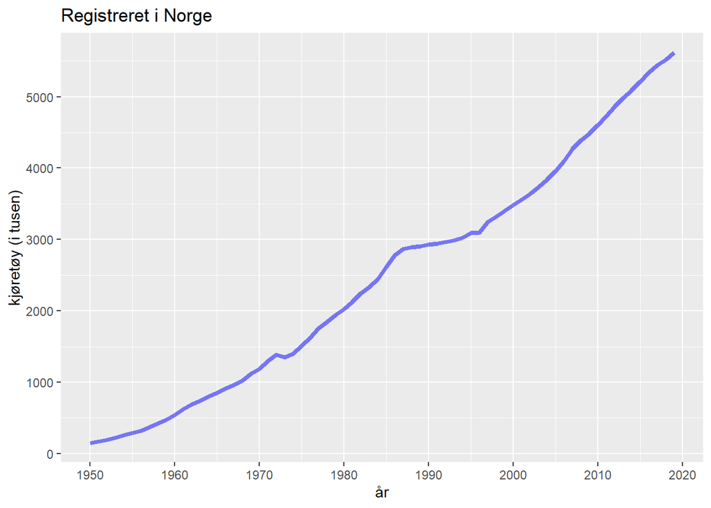

```r
registreret %>% filter (Typer == "Kjøretøy i alt") %>%
                ggplot (aes(x=år, y=vehic/1000)) +
                labs(title = "Registreret i Norge", x="år", y= "kjøretøy (i tusen)")+
                geom_line(alpha = 0.5, size = 1.5, color = "blue")+
                scale_y_continuous(breaks=seq(0,6000,by=1000))+
                scale_x_continuous(breaks=seq(1950,2020,by=10))
```

## Registrert i Norge etter kjøretøytype

### Graf

```
## `mutate_all()` ignored the following grouping variables:
## Columns `Typer`, `år`
## Use `mutate_at(df, vars(-group_cols()), myoperation)` to silence the message.
```

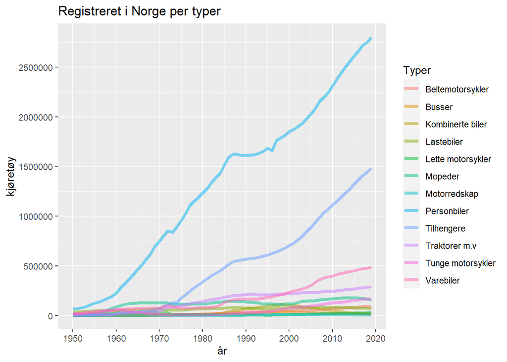

```r
registreret %>% filter (Typer != "Kjøretøy i alt") %>%
                group_by (Typer, år ) %>%
                mutate_all(~replace(., is.na(.), 0))%>%
                #summarize(sum_veh = sum(vehic)) %>%
                ggplot (aes(x=år, y=vehic, color = Typer)) +
                labs(title = "Registreret i Norge per typer", x="år", y= "kjøretøy")+
                geom_line(alpha = 0.5, size = 1.5)+
                scale_y_continuous(breaks=seq(0,3000000,by=500000))+
                scale_x_continuous(breaks=seq(1950,2025,by=10))
```

### Tabell

```r
Total_2019 <- registreret %>%
  filter (Typer != "Kjøretøy i alt" & år == 2019)%>%
  summarise(sum(vehic, na.rm = TRUE ))


registreret %>% filter (Typer != "Kjøretøy i alt" & år == 2019) %>%
  group_by (Typer, år ) %>%
  arrange (desc(vehic)) %>%
  # summarise(total(sum(vehic, na.rm = TRUE))) %>%
  # mutate(prosent = paste0(round(100*vehic / total ,2),"%"))
  #mutate(prosent = paste0(round(100*vehic /sum(vehic, na.rm = TRUE),2),"%")) %>%
  mutate(prosent = paste0(round(100*vehic / Total_2019,2),"%")) %>%
  kable() %>%
  kable_styling(full_width = F, position = "center", font_size = 10) %>%
  column_spec(column = 3, width = "2cm", background = "orange", color = "black") %>%
  row_spec(row = 0, background="green", bold=T, color="white")
```

| Typer | år | vehic | prosent |
| --- | --- | --- | --- |
| Personbiler | 2019 | 2801208 | 49.82% |
| Tilhengere | 2019 | 1481816 | 26.35% |
| Varebiler | 2019 | 489417 | 8.7% |
| Traktorer m.v | 2019 | 291841 | 5.19% |
| Tunge motorsykler | 2019 | 170249 | 3.03% |
| Mopeder | 2019 | 159273 | 2.83% |
| Beltemotorsykler | 2019 | 91931 | 1.63% |
| Lastebiler | 2019 | 72078 | 1.28% |
| Lette motorsykler | 2019 | 28223 | 0.5% |
| Busser | 2019 | 15867 | 0.28% |
| Kombinerte biler | 2019 | 14830 | 0.26% |
| Motorredskap | 2019 | 6463 | 0.11% |

## Total Registrert etter kommuner i 2019 i Norge

**Data nedlasting:** 11823: Registrerte kjøretøy, etter region, drivstofftype, statistikkvariabel og år https://www.ssb.no/bilreg

```r
library(readxl)
comb_kom_2019 <- read_excel("C:/mio/Big/estudios_mv/comb_kom_2019.xlsx",
    sheet = "Hoja1")
View(comb_kom_2019)
```

### Tabell

```r
kommune <- comb_kom_2019

kommune %>%
  group_by(Kom) %>%
  summarize(t2019 = sum(tall)) %>%
  arrange(desc(t2019)) %>%
  slice(1:10) %>%
    kable() %>%
  kable_styling(full_width = F, position = "center", font_size = 10) %>%
  row_spec(row = 0, background="green", bold=T, color="white")
```

| Kom | t2019 |
| --- | --- |
| Oslo | 431872 |
| Bærum | 161045 |
| Bergen | 148988 |
| Trondheim | 118735 |
| Drammen | 87302 |
| Stavanger | 82805 |
| Kristiansand | 66047 |
| Asker | 61088 |
| Lillestrøm | 56950 |
| Fredrikstad | 54910 |

### Drivstofftype - 2019

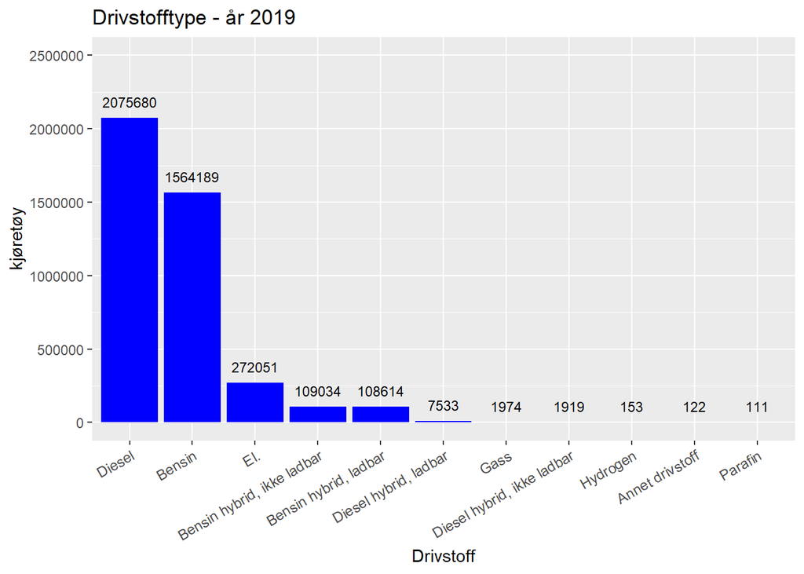

```r
kommune %>%
  #filter(ar == 2019)%>%
  group_by(drivstofftype) %>%
  summarize(total_anual = sum(tall))%>%
  ggplot(aes(reorder(drivstofftype,-total_anual),total_anual))+
  geom_bar(stat="identity" , fill = "blue")+
  labs(title = "Drivstofftype - år 2019", x="Drivstoff", y= "kjøretøy")+
  geom_text(aes(label = total_anual,  vjust=-1 ), size = 3)+
  theme(axis.text.x = element_text(angle = 30, hjust=1, size = 9))+
  scale_y_continuous(limit = c(0,2500000), breaks=seq(0,2500000,by=500000))
```

### Diesel Kjoretoy

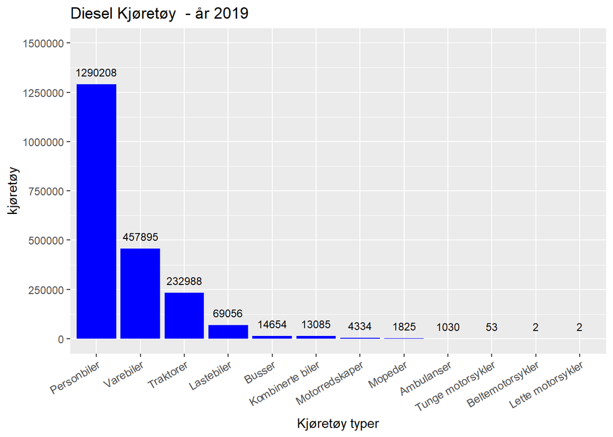

```r
kommune %>%
  filter(drivstofftype == "Diesel" | drivstofftype == "Diesel hybrid, ladbar" |drivstofftype == "Diesel hybrid, ikke ladbar" )%>%
  group_by(kjøretøy) %>%
  summarize(total_anual = sum(tall))%>%
  ggplot(aes(reorder(kjøretøy ,-total_anual),total_anual))+
  geom_bar(stat="identity" , fill = "blue")+
  labs(title = "Diesel Kjøretøy  - år 2019", x="Kjøretøy typer", y= "kjøretøy")+
  geom_text(aes(label = total_anual,vjust=-1 ), size = 3)+
  theme(axis.text.x = element_text(angle = 30, hjust=1, size = 9))+
  scale_y_continuous(limit = c(0,1500000), breaks=seq(0,1500000,by=250000))
```

## Bilmarker

**Data nedlasting:** 08581: Registrerte person- og varebiler, etter bilmerke, statistikkvariabel og år https://www.ssb.no/bilreg

```r
library(readr)
marker_bil_2019 <- read_delim("C:/mio/Big/estudios_mv/marker_bil_2019.csv",
    ";", escape_double = FALSE, locale = locale(encoding = "ISO-8859-1"),
    trim_ws = TRUE)
View(marker_bil_2019)
```

#Bilmerker

## Audi i Norge

```r
marker <- marker_bil_2019
colnames(marker)
```

```
## [1] "bilmerke"                     "alder"
## [3] "Registrerte personbiler 2019" "Registrerte varebiler 2019"
```

```r
names(marker) <- c("bilmerke", "alder", "personbiler2019", "varebiler2019")

# Tabell

marker %>%
  group_by(bilmerke)%>%
  summarise(total_bil= sum(personbiler2019))%>%
  filter(total_bil > 100000) %>%
  mutate(rank = rank(-total_bil))%>%
  arrange(desc(total_bil)) %>%
  kable() %>%
  kable_styling(full_width = F, position = "center", font_size = 10) %>%
  row_spec(row = 0, background="green", bold=T, color="white") %>%
  row_spec(row = 7, background="yellow", bold=T, color="black")
```

| bilmerke | total_bil | rank |
| --- | --- | --- |
| Volkswagen | 393642 | 1 |
| Toyota | 346101 | 2 |
| Volvo | 228511 | 3 |
| Ford | 162575 | 4 |
| Mercedes-Benz | 160252 | 5 |
| Bmw | 157747 | 6 |
| Audi | 152246 | 7 |
| Nissan | 131069 | 8 |
| Skoda | 102845 | 9 |

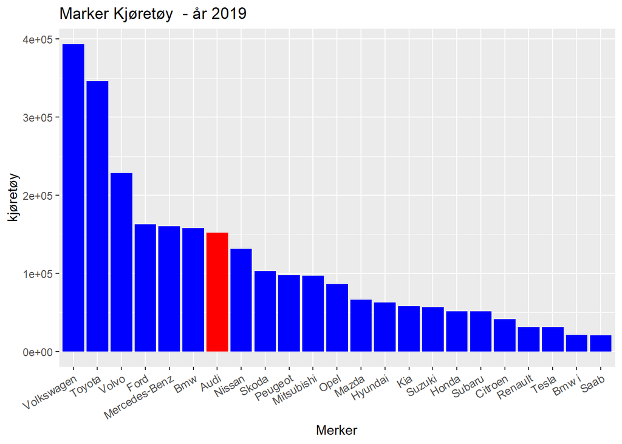

```r
# Graf

marker %>%
  group_by(bilmerke)%>%
  summarise (tot_merke = sum(personbiler2019)) %>%
  filter (tot_merke >20000)%>%
  arrange(desc(tot_merke)) %>%
  ggplot(aes(reorder(bilmerke,-tot_merke),tot_merke, fill = bilmerke == "Audi"))+
  scale_fill_manual(values = c("blue", "red"))+
  geom_bar(stat="identity") +
  guides(fill=FALSE)+
  labs(title = "Marker Kjøretøy  - år 2019", x="Merker", y= "kjøretøy")+
  theme(axis.text.x = element_text(angle = 30, hjust=1, size = 9))
```

Alder på personbiler i Norge (2019)

```r
marker$alder <- as.factor(marker$alder)
#levels(marker$alder)
# Para cambiar este orden usamos la funcion "factor".
marker$alder = factor(marker$alder, levels=c("Under 4 år", "4 - 7 år", "8 - 11 år", "12 - 15 år", "16 - 20 år", "Over 20 år"))
#levels(marker$alder)
```

## Audi og alle andre merker

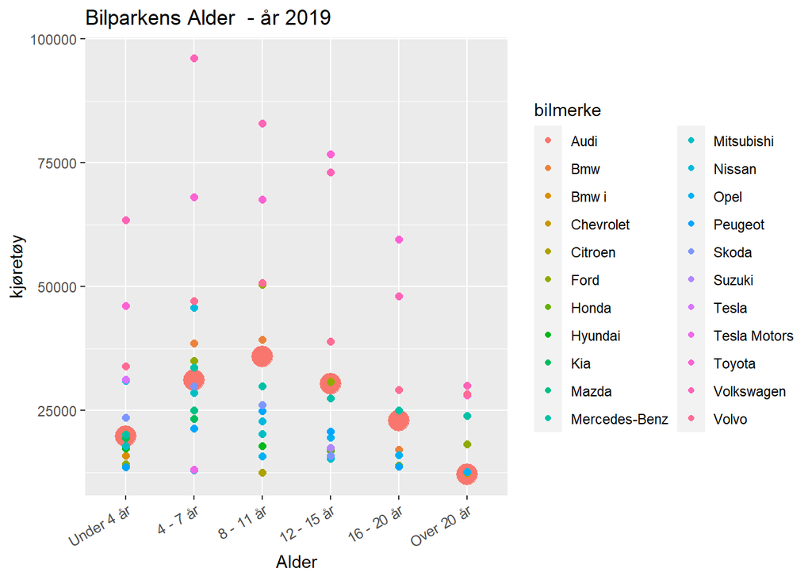

```r
marker %>%
  dplyr::select(-varebiler2019)%>%
  group_by(alder, bilmerke)%>%
  summarise(total_bil= sum(personbiler2019))%>%
  filter(total_bil > 12000) %>%
  ggplot(aes(x= alder, y = total_bil, color = bilmerke, size= bilmerke == "Audi"))+
  #scale_color_manual(values = c("blue", "red"))+
  geom_point() +
  guides(size=FALSE)+
  labs(title = "Bilparkens Alder  - år 2019", x="Alder", y= "kjøretøy")+
  theme(axis.text.x = element_text(angle = 30, hjust=1, size = 9))
```

```r
  #scale_y_continuous(limit = c(0,100000), breaks=seq(0,100000,by=10000))
  #+geom_jitter()
```

## Audi-biler registrert i Norge fra perioden solgt mellom 2009 og 2015

```r
marker %>%
  filter (bilmerke =="Audi")%>%
  group_by(alder)%>%
  dplyr::select(alder,personbiler2019) %>%
  kable() %>%
  kable_styling(full_width = F, position = "center", font_size = 10)%>%
  row_spec(row = 0, background="green", bold=T, color="white") %>%
  row_spec(row = 2:3, background="yellow", bold=T, color="black")
```

| alder | personbiler2019 |
| --- | --- |
| Under 4 år | 19841 |
| 4 - 7 år | 31098 |
| 8 - 11 år | 35915 |
| 12 - 15 år | 30363 |
| 16 - 20 år | 22919 |
| Over 20 år | 12110 |

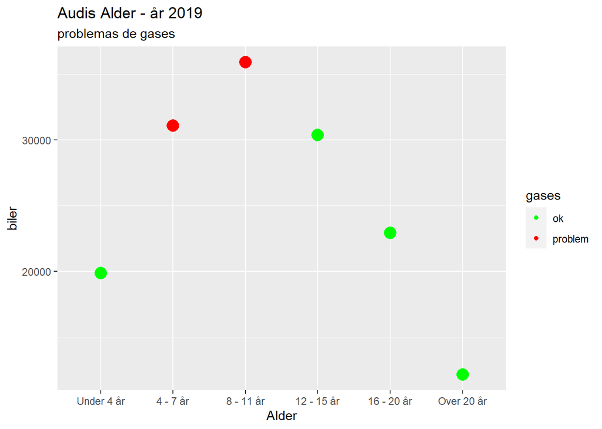

```r
marker %>%
  filter (bilmerke =="Audi")%>%
  group_by(alder)%>%
  dplyr::select(alder,personbiler2019) %>%
  ggplot(aes(alder, personbiler2019, size = 15,
             color = (alder == "4 - 7 år"  | alder == "8 - 11 år")))+
  geom_point() +
  #scale_color_manual(values = c("blue", "red"))+
  scale_colour_manual("gases", labels = c("ok", "problem"),values = c("green","red"))+
  guides(size=FALSE)+
  labs(title = "Audis Alder - år 2019", x="Alder", y= "biler", subtitle = "problemas de gases")
```

# Estudio de vehiculos per capita ?????

Fylker-Kommuner

```r
library(readxl)
kommuner_fylker <- read_excel("C:/mio/Big/estudios_mv/kommuner_fylker.xlsx")
# View(kommuner_fylker)
```

11342: Areal og befolkning, etter region, statistikkvariabel og år

```r
library(readxl)
Folkemengde_2020 <- read_excel("C:/mio/Big/estudios_mv/Folkemengde_2020.xlsx")
# View(Folkemengde_2020)
```

Unir_tablas

```r
kf_befolk <- merge(Folkemengde_2020, kommuner_fylker, by.x="kodekomm", by.y= "Kommunenummer", all.x=TRUE)

kf_befolk_bilpark <- merge (kommune, kf_befolk, by.x="Kom", by.y="Kommunar", all.x = TRUE)
```

coches por habitante

```r
kf_befolk_bilpark %>%
  group_by(Kom) %>%
  summarize(K2019= sum(tall),
            Kpc= round(sum(tall/Befolkning_2020),2),
            Bef_k= mean(Befolkning_2020)) %>%
  dplyr::select(Kom,K2019,Bef_k, Kpc)%>%
  arrange(desc(Kpc)) %>%
  slice(1:10) %>%
    kable() %>%
  kable_styling(full_width = F, position = "center", font_size = 10) %>%
  row_spec(row = 0, background="green", bold=T, color="white")
```

| Kom | K2019 | Bef_k | Kpc |
| --- | --- | --- | --- |
| Åseral | 1561 | 932 | 1.67 |
| Valle | 1912 | 1164 | 1.64 |
| Nore og Uvdal | 3960 | 2439 | 1.62 |
| Guovdageaidnu - Kautokeino | 4676 | 2910 | 1.61 |
| Lierne | 2150 | 1355 | 1.59 |
| Raarvihke - Røyrvik | 727 | 461 | 1.58 |
| Hægebostad | 2585 | 1680 | 1.54 |
| Tydal | 1186 | 769 | 1.54 |
| Sigdal | 5304 | 3467 | 1.53 |
| Deatnu - Tana | 4438 | 2918 | 1.52 |

Coches por habitante en poblaciones grandes

```r
kf_befolk_bilpark %>%
  group_by(Kom) %>%
  summarize(K2019= sum(tall),
            Kpc= round(sum(tall/Befolkning_2020),2),
            Bef_k= mean(Befolkning_2020)) %>%
  filter(Bef_k > 100000) %>%
  dplyr::select(Kom,K2019,Bef_k, Kpc)%>%
  arrange(desc(Kpc)) %>%
  slice(1:10) %>%
    kable() %>%
  kable_styling(full_width = F, position = "center", font_size = 10) %>%
  row_spec(row = 0, background="green", bold=T, color="white")
```

| Kom | K2019 | Bef_k | Kpc |
| --- | --- | --- | --- |
| Bærum | 161045 | 127731 | 1.26 |
| Drammen | 87302 | 101386 | 0.86 |
| Oslo | 431872 | 693494 | 0.62 |
| Kristiansand | 66047 | 111633 | 0.59 |
| Stavanger | 82805 | 143574 | 0.58 |
| Trondheim | 118735 | 205163 | 0.58 |
| Bergen | 148988 | 283929 | 0.52 |

Archivos conjunto bueno

```r
# write.csv(kf_befolk_bilpark, "C:/mio/Big/estudios_mv/tabla1.csv")
```

Coches por habitante por Fylke

```r
befolk_F <- kf_befolk %>% group_by(Fylke) %>% summarize (bef_f = sum(Befolkning_2020))
befolk_Norge <- sum(befolk_F$bef_f) # comprobacion poblacion de noruega en 2019 (5367580 innbyggere)

## vehiculos per capita per capita

kf_befolk_bilpark %>%
  group_by(Fylke) %>%
  left_join(befolk_F)%>%
  summarize(K2019= sum(tall),
            Bef_k= mean(bef_f),
            Kpc= round(K2019/Bef_k,2)) %>%
  #filter(Bef_k > 100000) %>%
  dplyr::select(Fylke,K2019,Bef_k, Kpc)%>%
  arrange(desc(Kpc)) %>%
  slice(1:11) %>%
    kable() %>%
  kable_styling(full_width = F, position = "center", font_size = 10) %>%
  row_spec(row = 0, background="green", bold=T, color="white")
```

| Fylke | K2019 | Bef_k | Kpc |
| --- | --- | --- | --- |
| Innlandet | 367086 | 371385 | 0.99 |
| Viken | 1000520 | 1241165 | 0.81 |
| Vestfold og Telemark | 325952 | 419396 | 0.78 |
| Møre og Romsdal | 203746 | 265238 | 0.77 |
| Agder | 234050 | 307231 | 0.76 |
| Troms og Finnmark - Romsa ja Finnmárku - Tromssa ja Finmarkku | 175273 | 243311 | 0.72 |
| Trøndelag - Trööndelage | 330877 | 468702 | 0.71 |
| Nordland | 168674 | 241235 | 0.70 |
| Rogaland | 330526 | 479892 | 0.69 |
| Vestland | 428938 | 636531 | 0.67 |
| Oslo | 431872 | 693494 | 0.62 |

Presentacion con datos geográficos

```r
library(sf)
gdb_norge_F <-  st_read("C:/mio/Big/SIG/Norge/FGDB/Basisdata_0000_Norge_25833_Fylker_FGDB.gdb/a0000000e.gdbtable")
gdb_norge_F$objid_f <- as.factor(gdb_norge_F$objid)

# Preparacion datos gdb (no aparecen el nombre de comunas)

fylke <- kf_befolk_bilpark %>% drop_na() %>% distinct(Fylke)

fylke_datos <- kf_befolk_bilpark %>%
  group_by(Fylke) %>%
  summarize( K2019 = sum(tall))%>%
  drop_na() %>%
  left_join(befolk_F, by = "Fylke")%>%
  mutate(Kpc= K2019/bef_f)
gdb_norge_F$Fylke  <- as.factor(c("Vestfold og Telemark","Agder","Viken","Rogaland","Nordland","Møre og Romsdal","Vestland" ,"Oslo" , "Trøndelag - Trööndelage", "Troms og Finnmark - Romsa ja Finnmárku - Tromssa ja Finmarkku" , "Innlandet"))


gdb_norge_datos <- gdb_norge_F %>%
  left_join(fylke_datos)
```

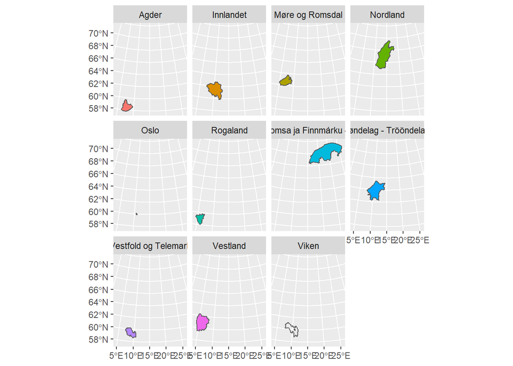

```r
ggplot(data = gdb_norge_datos)+
  geom_sf(aes(fill = Fylke), show.legend = FALSE)+
  facet_wrap(~ Fylke)
```

Graficos pro kommuner

```r
gdb_norge_K <-  st_read("C:/mio/Big/SIG/Norge/FGDB/Basisdata_0000_Norge_25833_Kommuner_FGDB.gdb/a0000000e.gdbtable")
class(gdb_norge_K)
```

```
## [1] "sf"         "data.frame"
```

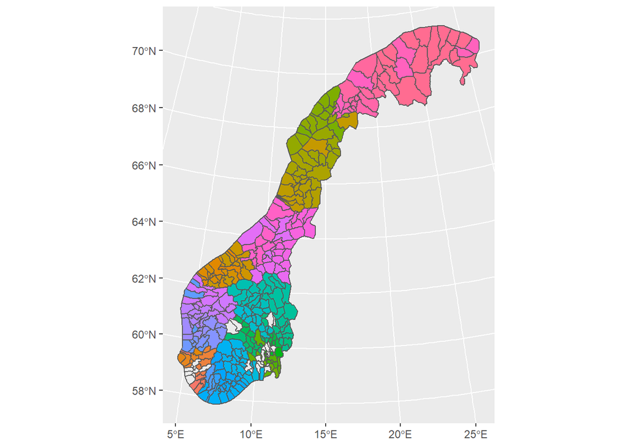

```r
ggplot(data = gdb_norge_K)+
  geom_sf(aes(fill = kommunenummer), show.legend = FALSE)
```

Repasemos las cifras de vehiculos por cápita por Kommune

```r
kf_befolk_bilpark %>%
  group_by(Kom) %>%
  summarize(K2019= sum(tall),
            Kpc= round(sum(tall/Befolkning_2020),2),
            Bef_k= mean(Befolkning_2020)) %>%
  dplyr::select(Kom,K2019,Bef_k, Kpc)%>%
  arrange(desc(Kpc)) %>%
  slice(1:10) %>%
    kable() %>%
  kable_styling(full_width = F, position = "center", font_size = 10) %>%
  row_spec(row = 0, background="green", bold=T, color="white")
```

| Kom | K2019 | Bef_k | Kpc |
| --- | --- | --- | --- |
| Åseral | 1561 | 932 | 1.67 |
| Valle | 1912 | 1164 | 1.64 |
| Nore og Uvdal | 3960 | 2439 | 1.62 |
| Guovdageaidnu - Kautokeino | 4676 | 2910 | 1.61 |
| Lierne | 2150 | 1355 | 1.59 |
| Raarvihke - Røyrvik | 727 | 461 | 1.58 |
| Hægebostad | 2585 | 1680 | 1.54 |
| Tydal | 1186 | 769 | 1.54 |
| Sigdal | 5304 | 3467 | 1.53 |
| Deatnu - Tana | 4438 | 2918 | 1.52 |

```r
# Vamos a analizar la kommuna con más vehiculos

kf_befolk_bilpark %>%
  filter(Kom =="Åseral")%>%
  group_by(kjøretøy) %>%
  summarize(K2019= sum(tall),
            Kpc= round(sum(tall/Befolkning_2020),2),
            Bef_k= mean(Befolkning_2020)) %>%
     mutate(prosent = paste0(round(100*K2019 / sum(K2019),2),"%")) %>%
  arrange(desc(K2019)) %>%
  kable() %>%
  kable_styling(full_width = F, position = "center", font_size = 10) %>%
  row_spec(row = 0, background="green", bold=T, color="white")
```

| kjøretøy | K2019 | Kpc | Bef_k | prosent |
| --- | --- | --- | --- | --- |
| Personbiler | 576 | 0.62 | 932 | 36.9% |
| Traktorer | 336 | 0.36 | 932 | 21.52% |
| Beltemotorsykler | 335 | 0.36 | 932 | 21.46% |
| Varebiler | 170 | 0.18 | 932 | 10.89% |
| Mopeder | 53 | 0.06 | 932 | 3.4% |
| Tunge motorsykler | 31 | 0.03 | 932 | 1.99% |
| Lastebiler | 30 | 0.03 | 932 | 1.92% |
| Motorredskaper | 18 | 0.02 | 932 | 1.15% |
| Kombinerte biler | 6 | 0.01 | 932 | 0.38% |
| Lette motorsykler | 4 | 0.00 | 932 | 0.26% |
| Busser | 2 | 0.00 | 932 | 0.13% |
| Ambulanser | 0 | 0.00 | 932 | 0% |

```r
#En esta poblacion hay muchos tractores y muchas motonieves
```

Datos por Kommunas

```r
colnames(gdb_norge_K)
```

```
##  [1] "objid"                    "objtype"
##  [3] "kommunenummer"            "samiskforvaltningsomrade"
##  [5] "lokalid"                  "navnerom"
##  [7] "versjonid"                "datafangstdato"
##  [9] "oppdateringsdato"         "datauttaksdato"
## [11] "opphav"                   "SHAPE_Length"
## [13] "SHAPE_Area"               "SHAPE"
```

```r
kf_befolk_bilpark <- kf_befolk_bilpark %>%
  mutate(kodekomm = as.character(kodekomm))


kommuner_datos <- kf_befolk_bilpark %>%
  group_by(Kom, kjøretøy) %>%
  dplyr::select(Kom,kodekomm, kjøretøy, tall, Befolkning_2020  )%>%
  rename(kommunenummer = kodekomm)

gdb_norge_datos_K <- gdb_norge_K %>%
  left_join(kommuner_datos)
```

Estadisticas sobre planos

```r
# Calcularemos donde existen más motos de nieve (en número) y porcentaje sobre las existentes en Noruega

kf_befolk_bilpark %>%
  group_by(Kom) %>%
  filter(kjøretøy == "Beltemotorsykler")%>%
  summarize(K2019= sum(tall),
            Kpc= round(sum(tall/Befolkning_2020),2),
            Bef_k= mean(Befolkning_2020)) %>%
     mutate(prosent = paste0(round(100*K2019 / sum(K2019),2),"%")) %>%
  arrange(desc(K2019)) %>%
  kable() %>%
  kable_styling(full_width = F, position = "center", font_size = 10) %>%
  row_spec(row = 0, background="green", bold=T, color="white")
```

| Kom | K2019 | Kpc | Bef_k | prosent |
| --- | --- | --- | --- | --- |
| Alta | 5129 | 0.25 | 20789 | 5.58% |
| Tromsø | 3182 | 0.04 | 76974 | 3.46% |
| Sør-Varanger | 3094 | 0.30 | 10158 | 3.37% |
| Rana | 2493 | 0.10 | 26184 | 2.71% |
| Hammerfest | 2309 | NA | NA | 2.51% |
| Svalbard og Jan Mayen | 2192 | NA | NA | 2.38% |
| Delte kommuner og uoppgitt | 2183 | NA | NA | 2.37% |
| Porsanger - Porsángu - Porsanki | 1800 | NA | NA | 1.96% |
| Trondheim | 1614 | 0.01 | 205163 | 1.76% |
| Vefsn | 1513 | 0.11 | 13278 | 1.65% |
| Bodø | 1464 | 0.03 | 52357 | 1.59% |
| Guovdageaidnu - Kautokeino | 1461 | 0.50 | 2910 | 1.59% |
| Vadsø | 1362 | 0.24 | 5788 | 1.48% |
| Oslo | 1324 | 0.00 | 693494 | 1.44% |
| Fauske - Fuosko | 1227 | NA | NA | 1.33% |
| Deatnu - Tana | 1153 | 0.40 | 2918 | 1.25% |
| Hemnes | 1127 | 0.25 | 4454 | 1.23% |
| Kárásjohka - Karasjok | 1054 | NA | NA | 1.15% |
| Nordreisa | 1008 | NA | NA | 1.1% |
| Vinje | 984 | 0.27 | 3676 | 1.07% |
| Målselv | 949 | 0.14 | 6640 | 1.03% |
| Senja | 916 | 0.06 | 14851 | 1% |
| Steinkjer | 891 | 0.04 | 24357 | 0.97% |
| Midtre Gauldal | 848 | 0.14 | 6238 | 0.92% |
| Saltdal | 833 | 0.18 | 4671 | 0.91% |
| Bardu | 786 | 0.20 | 4005 | 0.85% |
| Balsfjord | 759 | 0.14 | 5559 | 0.83% |
| Melhus | 735 | 0.04 | 16733 | 0.8% |
| Selbu | 712 | 0.18 | 4062 | 0.77% |
| Stjørdal | 709 | 0.03 | 24145 | 0.77% |

[output cut: 329 more lines]

```r
# Calcularemos más motos de nieve per capita

kf_befolk_bilpark %>%
  group_by(Kom) %>%
  filter(kjøretøy == "Beltemotorsykler")%>%
  summarize(K2019= sum(tall),
            Kpc= round(sum(tall/Befolkning_2020),2),
            Bef_k= mean(Befolkning_2020)) %>%
     mutate(prosent = paste0(round(100*K2019 / sum(K2019),2),"%")) %>%
  arrange(desc(Kpc)) %>%
  kable() %>%
  kable_styling(full_width = F, position = "center", font_size = 10) %>%
  row_spec(row = 0, background="green", bold=T, color="white")
```

| Kom | K2019 | Kpc | Bef_k | prosent |
| --- | --- | --- | --- | --- |
| Guovdageaidnu - Kautokeino | 1461 | 0.50 | 2910 | 1.59% |
| Raarvihke - Røyrvik | 220 | 0.48 | 461 | 0.24% |
| Lierne | 608 | 0.45 | 1355 | 0.66% |
| Valle | 490 | 0.42 | 1164 | 0.53% |
| Deatnu - Tana | 1153 | 0.40 | 2918 | 1.25% |
| Unjárga - Nesseby | 361 | 0.39 | 926 | 0.39% |
| Tydal | 292 | 0.38 | 769 | 0.32% |
| Åseral | 335 | 0.36 | 932 | 0.36% |
| Kvænangen | 364 | 0.31 | 1191 | 0.4% |
| Sør-Varanger | 3094 | 0.30 | 10158 | 3.37% |
| Hægebostad | 482 | 0.29 | 1680 | 0.52% |
| Berlevåg | 264 | 0.28 | 957 | 0.29% |
| Fyresdal | 348 | 0.27 | 1287 | 0.38% |
| Gamvik | 309 | 0.27 | 1132 | 0.34% |
| Storfjord - Omasvuotna - Omasvuono | 501 | 0.27 | 1829 | 0.54% |
| Vinje | 984 | 0.27 | 3676 | 1.07% |
| Bygland | 297 | 0.26 | 1162 | 0.32% |
| Engerdal | 331 | 0.26 | 1268 | 0.36% |
| Lebesby | 330 | 0.26 | 1290 | 0.36% |
| Namsskogan | 222 | 0.26 | 843 | 0.24% |
| Alta | 5129 | 0.25 | 20789 | 5.58% |
| Gáivuotna - Kåfjord - Kaivuono | 519 | 0.25 | 2071 | 0.56% |
| Hemnes | 1127 | 0.25 | 4454 | 1.23% |
| Holtålen | 498 | 0.25 | 1981 | 0.54% |
| Sirdal | 438 | 0.24 | 1822 | 0.48% |
| Vadsø | 1362 | 0.24 | 5788 | 1.48% |
| Båtsfjord | 507 | 0.23 | 2221 | 0.55% |
| Grane | 338 | 0.23 | 1482 | 0.37% |
| Beiarn | 228 | 0.22 | 1017 | 0.25% |
| Snåase - Snåsa | 454 | 0.22 | 2063 | 0.49% |

[output cut: 329 more lines]

Graficos

Komunner con mas de 1000 motosdenieve

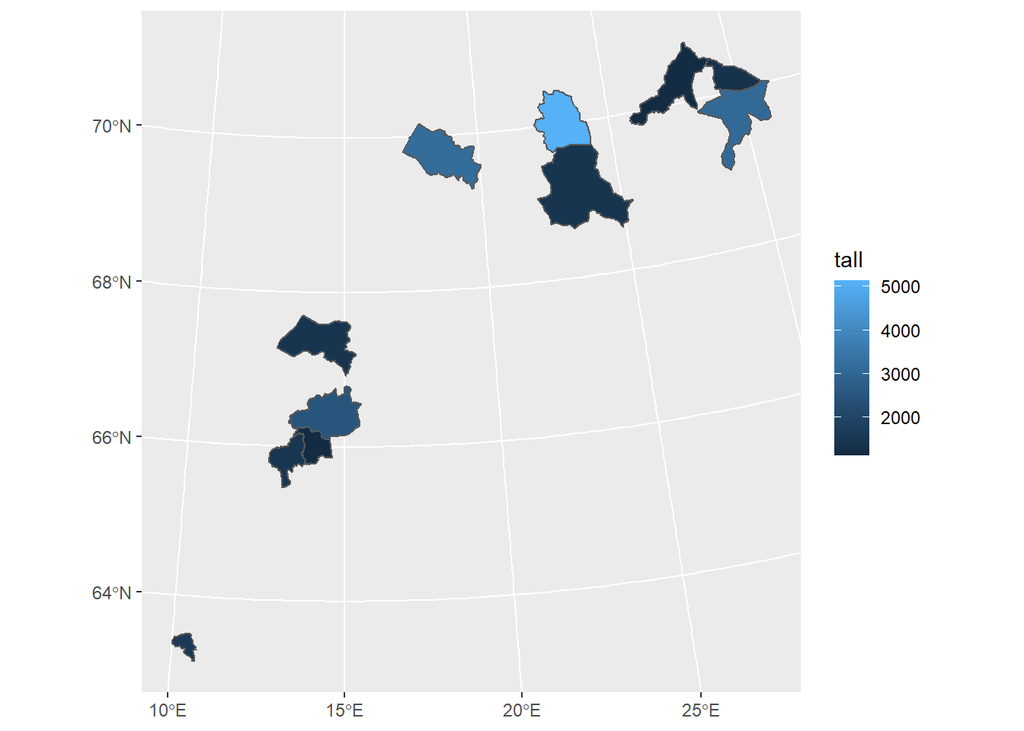

```r
ggplot(gdb_norge_datos_K %>% filter(kjøretøy == "Beltemotorsykler") %>% filter(tall > 1000)) +   geom_sf(aes(fill = tall))
```

Kommuner con más de 1000 traktorer

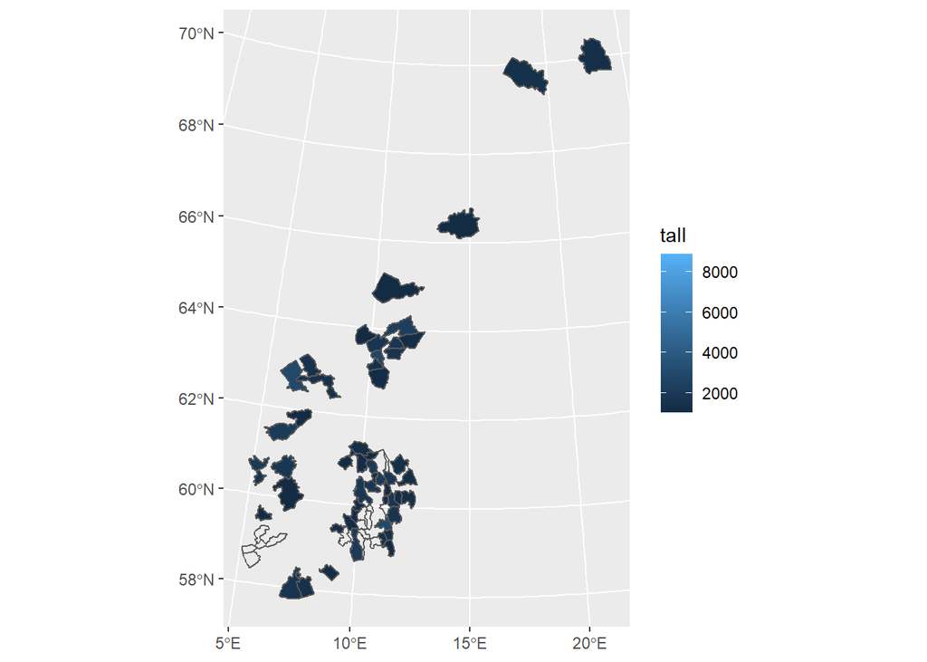

```r
ggplot(gdb_norge_datos_K %>% filter(kjøretøy == "Traktorer") %>% filter(tall > 1000)) +   geom_sf(aes(fill = tall))
```

Por porcentaje sobre el total de vehiculos

```r
# Prepararemos una tabla ancha por komunas donde calcularemos el porcentaje que hay de cada vehiculo

k_ancha <- kf_befolk_bilpark %>%
  group_by(Kom, kjøretøy)%>%
  summarize(kj = sum(tall))%>%
  spread(key   = kjøretøy, #key son los nombres de columnas
         value = kj) #los valores con que se llenan las celdas %>%
## comprobacion de valores NA

row.has.na <- apply(k_ancha, 1, function(x){any(is.na(x))})
sum(row.has.na) # No existen NA
```

```
## [1] 0
```

```r
# Vamos a incluir una columna de totales de vehiculos por kommuna

k_ancha <- as.data.frame(k_ancha) %>%
   mutate(tot_K = rowSums(.[2:13]))

# Porcentajes del turismos, traktores y motos de nieve sobre el total de vehiculos de la comuna

k_ancha$pre_pb = round(k_ancha$Personbiler/k_ancha$tot_K*100,1)
k_ancha$pre_tr = round(k_ancha$Traktorer/k_ancha$tot_K*100,1)
k_ancha$pre_bm = round(k_ancha$Beltemotorsykler/k_ancha$tot_K*100,1)
```

Poblaciones con mayor porcentaje de traktores sobre el total de vehiculos en la kommuna

```r
k_ancha %>% dplyr::select(Kom, pre_tr )%>%
  arrange(desc(pre_tr)) %>%
  slice(1:10) %>%
  kable() %>%
  kable_styling(full_width = F, position = "center", font_size = 10) %>%
  row_spec(row = 0, background="green", bold=T, color="white")
```

| Kom | pre_tr |
| --- | --- |
| Lesja | 27.0 |
| Tolga | 25.5 |
| Vang | 24.3 |
| Folldal | 24.2 |
| Hjelmeland | 24.1 |
| Skjåk | 23.9 |
| Lom | 23.6 |
| Rennebu | 23.4 |
| Dønna | 23.2 |
| Rødøy | 22.5 |

Poblaciones con mayor porcentaje de motos de nieve

```r
k_ancha %>% dplyr::select(Kom, pre_bm )%>%
  arrange(desc(pre_bm)) %>%
  slice(1:10) %>%
  kable() %>%
  kable_styling(full_width = F, position = "center", font_size = 10) %>%
  row_spec(row = 0, background="green", bold=T, color="white")
```

| Kom | pre_bm |
| --- | --- |
| Svalbard og Jan Mayen | 54.1 |
| Porsanger - Porsángu - Porsanki | 31.4 |
| Guovdageaidnu - Kautokeino | 31.2 |
| Raarvihke - Røyrvik | 30.3 |
| Gamvik | 29.3 |
| Kárásjohka - Karasjok | 29.1 |
| Berlevåg | 28.4 |
| Lierne | 28.3 |
| Lebesby | 26.9 |
| Unjárga - Nesseby | 26.9 |

# Carga de ficheros .shape de QGIS

```r
kommunerV <- shapefile("C:/mio/Big/SIG/Norge/FGDB/Basisdata_0000_Norge_25833_Kommuner_FGDB.gdb/kommuner.shp")
fylkerV <- shapefile("C:/mio/Big/SIG/Norge/FGDB/Basisdata_0000_Norge_25833_Kommuner_FGDB.gdb/fylker.shp")
```

informacion componente espacial

```r
geometry(kommunerV)
```

```
## class       : SpatialPolygons
## features    : 363
## extent      : -99551.21, 1121941, 6426048, 7962744  (xmin, xmax, ymin, ymax)
## crs         : +proj=utm +zone=33 +ellps=GRS80 +towgs84=0,0,0,0,0,0,0 +units=m +no_defs
```

```r
geometry(fylkerV)
```

```
## class       : SpatialLines
## features    : 18884
## extent      : -86015.82, 627600.6, 6466105, 7721400  (xmin, xmax, ymin, ymax)
## crs         : +proj=utm +zone=33 +ellps=GRS80 +towgs84=0,0,0,0,0,0,0 +units=m +no_defs
```

Tablas de datos

```r
#Poblacion_area_densidad_K

library(readxl)
Folkemengde_2020 <- read_excel("C:/mio/Big/estudios_mv/Folkemengde_2020.xlsx")
View(Folkemengde_2020)


# Relacion Komunner y Fylker

kommuner_fylker <- read_excel("C:/mio/Big/estudios_mv/kommuner_fylker.xlsx")
View(kommuner_fylker)

# drivstoff y kjoretoy_K
comb_kom_2019 <- read_excel("C:/mio/Big/estudios_mv/comb_kom_2019.xlsx",
    sheet = "Hoja1")
View(comb_kom_2019)
```

Unir_tablas

```r
kf_befolk <- merge(Folkemengde_2020, kommuner_fylker, by.x="kodekomm", by.y= "Kommunenummer", all.x=TRUE)



nrow(distinct(kf_befolk,kodekomm)) # numero de valores distintos 356
```

```
## [1] 356
```

```r
nrow(distinct(comb_kom_2019,kod)) # codigos 359
```

```
## [1] 359
```

```r
# vamos a separar la columna Kom en 2 dejando solo el codigo despues de "-"


comb_kom_2019 <- separate(data = comb_kom_2019, col = kod, into = c("letra", "kodekomm"), sep = "\\-")
nrow(distinct(comb_kom_2019,kodekomm)) # codigos 359
```

```
## [1] 359
```

```r
comb_kom_2019$kodekomm <- as.character(comb_kom_2019$kodekomm)

kf_befolk_bilpark <- merge (comb_kom_2019, kf_befolk, by="kodekomm")


nrow(distinct(kf_befolk_bilpark,kodekomm)) # numero de valores distintos 355
```

```
## [1] 355
```

tabla de datosV

```r
library(dplyr)

datosV <- kf_befolk_bilpark %>%
  group_by(Kom, kjøretøy) %>%
  rename(kommunenum = kodekomm)

length(unique(datosV$kommunenum)) # numero de valores distintos 355 !!!!!
```

```
## [1] 355
```

```r
# Vamos a comprobar que observaciones tienen NA
datosV_con_NA <- datosV[!complete.cases(datosV),]

# Existen registros de vehiculos con la denominación "Delte kommuner og uoppgitt".

# Eliminamos los registros con NA: datosV <- na.omit(datosV)
```

Vehiculos totales por kommuna

```r
kj_tab <- datosV %>% group_by(Kom, kommunenum, Fylke, Befolkning_2020) %>% summarize (total_kj = sum(tall))
Kj_K_V <- merge (kommunerV,
                 kj_tab,
                 by="kommunenum")
```

Poblaciones con más de 20.000 vehiculos

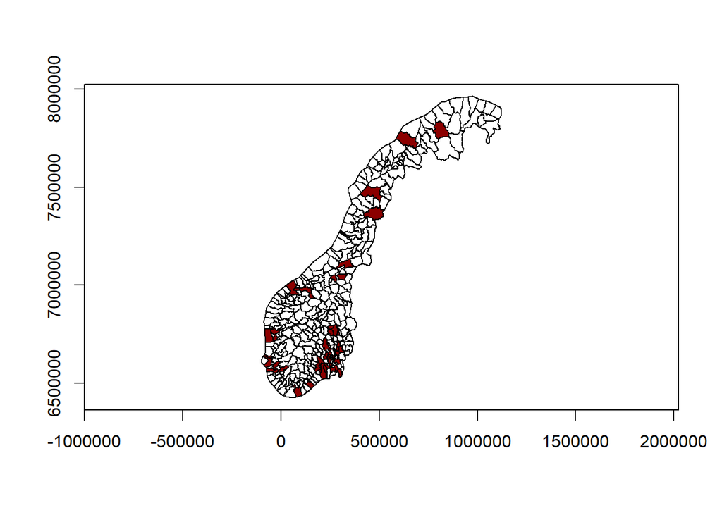

```r
over20M <- subset(Kj_K_V, subset = total_kj>20000)

plot (kommunerV, axes=TRUE)
plot (over20M, col ="darkred", add=TRUE)
```

Vehiculos per capita

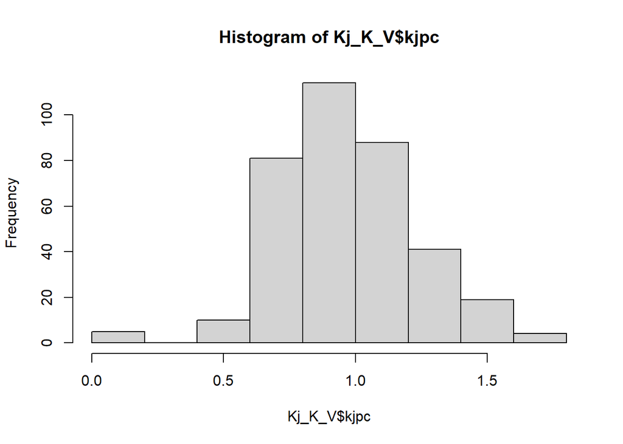

```r
# Creamos la variable: densidad de vehiculos per capita

Kj_K_V$kjpc = Kj_K_V$total_kj/Kj_K_V$Befolkning_2020

hist(Kj_K_V$kjpc)
```

```r
Kj_K_V$kjpc_f <- case_when(
  Kj_K_V$kjpc <= 0.5 ~ "< 0.5",
  Kj_K_V$kjpc <= 1 ~ "0.5 - 1.0",
  Kj_K_V$kjpc <= 1.5 ~ "1.0 - 1.5",
  Kj_K_V$kjpc > 1.5 ~ " > 1.5")

table(Kj_K_V$kjpc_f)
```

```
##
##     > 1.5     < 0.5 0.5 - 1.0 1.0 - 1.5
##        11         6       204       141
```

```r
Kj_K_V$kjpc_f <- as.factor(Kj_K_V$kjpc_f)
levels( Kj_K_V$kjpc_f )    # a, b, c
```

```
## [1] " > 1.5"    "< 0.5"     "0.5 - 1.0" "1.0 - 1.5"
```

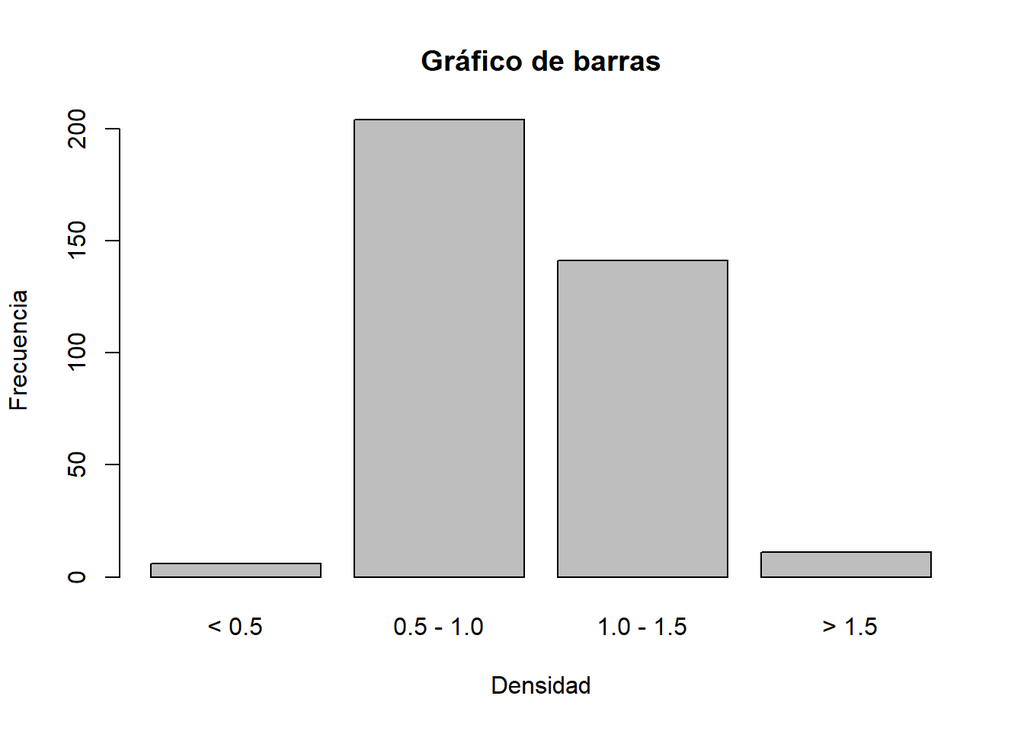

```r
Kj_K_V$kjpc_f <- factor(Kj_K_V$kjpc_f,
                      levels= levels(Kj_K_V$kjpc_f)[c(2,3,4,1)])

plot(Kj_K_V$kjpc_f, main = "Gráfico de barras",
     xlab = "Densidad", ylab = "Frecuencia")
```

```r
table(Kj_K_V$kjpc_f)
```

```
##
##     < 0.5 0.5 - 1.0 1.0 - 1.5     > 1.5
##         6       204       141        11
```

Grafica

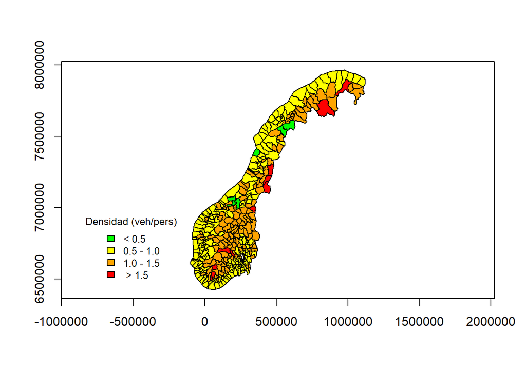

```r
# grafico

plot (kommunerV, axes=TRUE)
plot (Kj_K_V,
      col = c("green","yellow","orange","red")[Kj_K_V$kjpc_f],
      add=TRUE)
legend ("bottomleft", inset=.05,title = expression("Densidad (veh/pers)"), legend = c("< 0.5","0.5 - 1.0","1.0 - 1.5", " > 1.5" ), fill = c("green","yellow","orange","red"), Kj_K_V$kjpc_f, cex=0.8, box.col = NA)
```

Plano comunas con menos y más coches por habitante

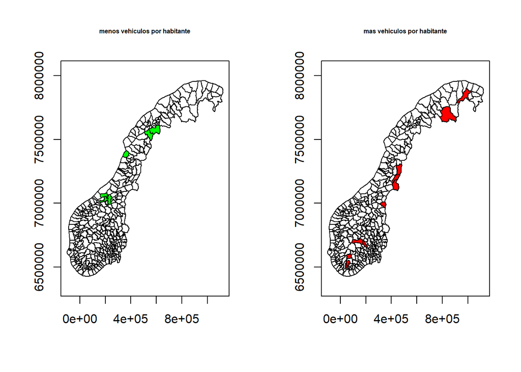

```r
mindre <- subset(Kj_K_V,kjpc < 0.5 )
mer <- subset(Kj_K_V,kjpc > 1.5 )

par(mfrow = c(1,2))
plot (kommunerV, axes=TRUE, main = "menos vehiculos por habitante", cex.main =0.5)
plot (mindre, col = "green", add=TRUE)

plot (kommunerV, axes=TRUE, main = "mas vehiculos por habitante", cex.main=0.5)
plot (mer, col = "red", add=TRUE)
```

Fylke Vestland

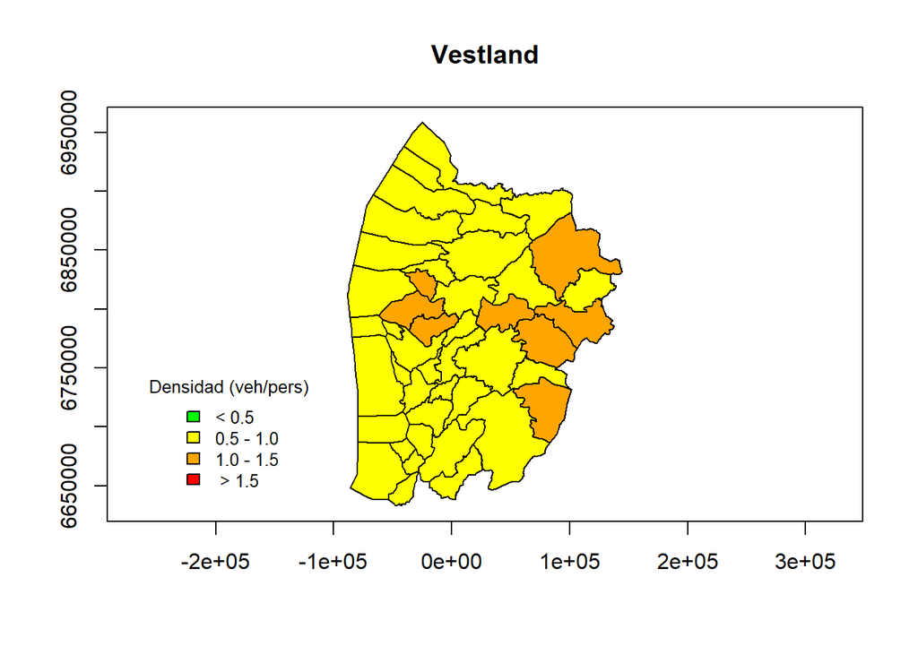

```r
KjpcVestland <- subset(Kj_K_V,Fylke == "Vestland")

plot (KjpcVestland,
      col = c("green","yellow","orange","red")[KjpcVestland$kjpc_f],
      axes=TRUE, main = "Vestland")
legend ("bottomleft", inset=.05,title = expression("Densidad (veh/pers)"), legend = c("< 0.5","0.5 - 1.0","1.0 - 1.5", " > 1.5" ), fill = c("green","yellow","orange","red"), KjpcVestland$kjpc_f, cex=0.8, box.col = NA)
```

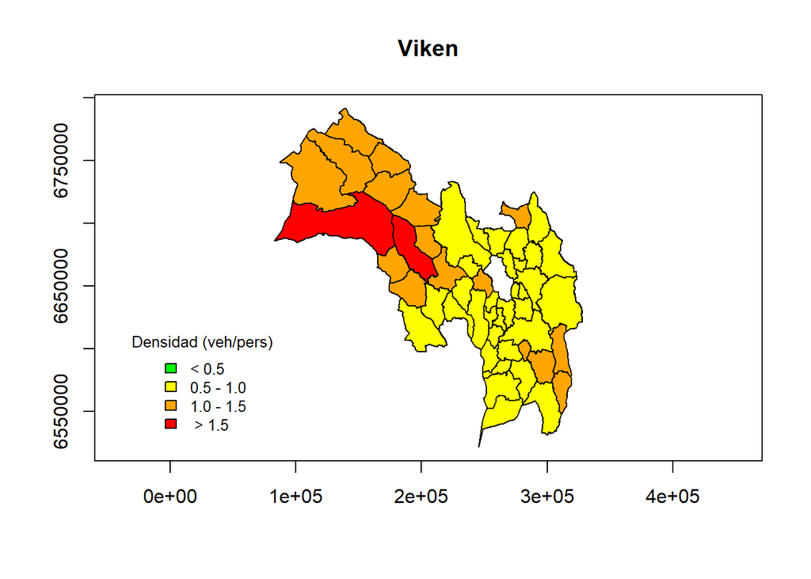

```r
KjpcViken <- subset(Kj_K_V, Fylke == "Viken")

plot (KjpcViken,
      col = c("green","yellow","orange","red")[KjpcViken$kjpc_f],
      axes=TRUE, main = "Viken")
legend ("bottomleft", inset=.05,title = expression("Densidad (veh/pers)"), legend = c("< 0.5","0.5 - 1.0","1.0 - 1.5", " > 1.5" ), fill = c("green","yellow","orange","red"), KjpcViken$kjpc_f, cex=0.8, box.col = NA)
```

Fylke Troms og Finnmark

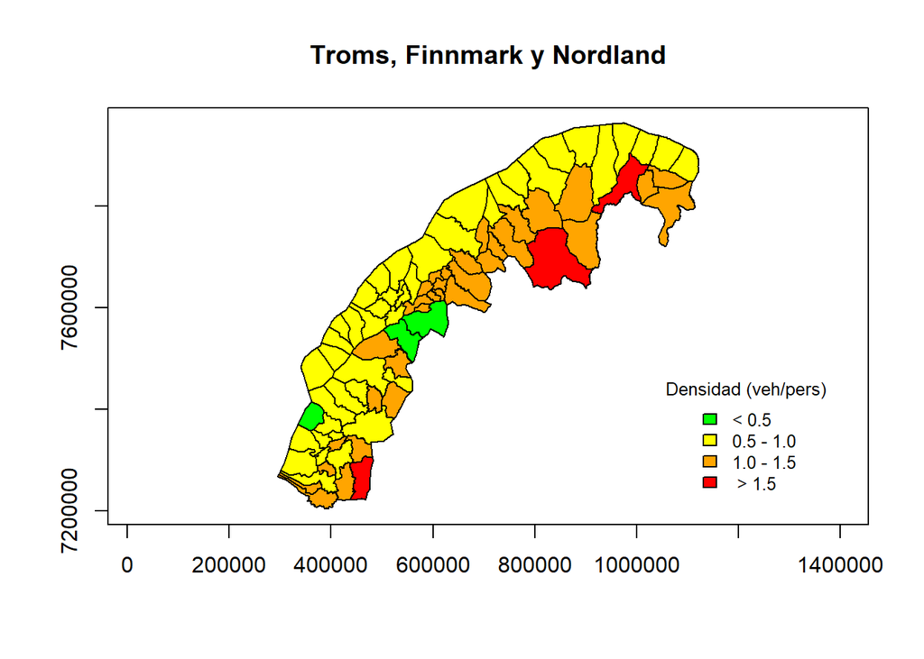

```r
KjpcTFN <- subset(Kj_K_V, Fylke == "Troms og Finnmark - Romsa ja Finnmárku - Tromssa ja Finmarkku" | Fylke == "Nordland")


plot (KjpcTFN,
      col = c("green","yellow","orange","red")[KjpcTFN$kjpc_f],
      axes=TRUE, main = "Troms, Finnmark y Nordland")
legend ("bottomright", inset=.05,title = expression("Densidad (veh/pers)"), legend = c("< 0.5","0.5 - 1.0","1.0 - 1.5", " > 1.5" ), fill = c("green","yellow","orange","red"), KjpcTFN$kjpc_f, cex=0.8, box.col = NA)
```

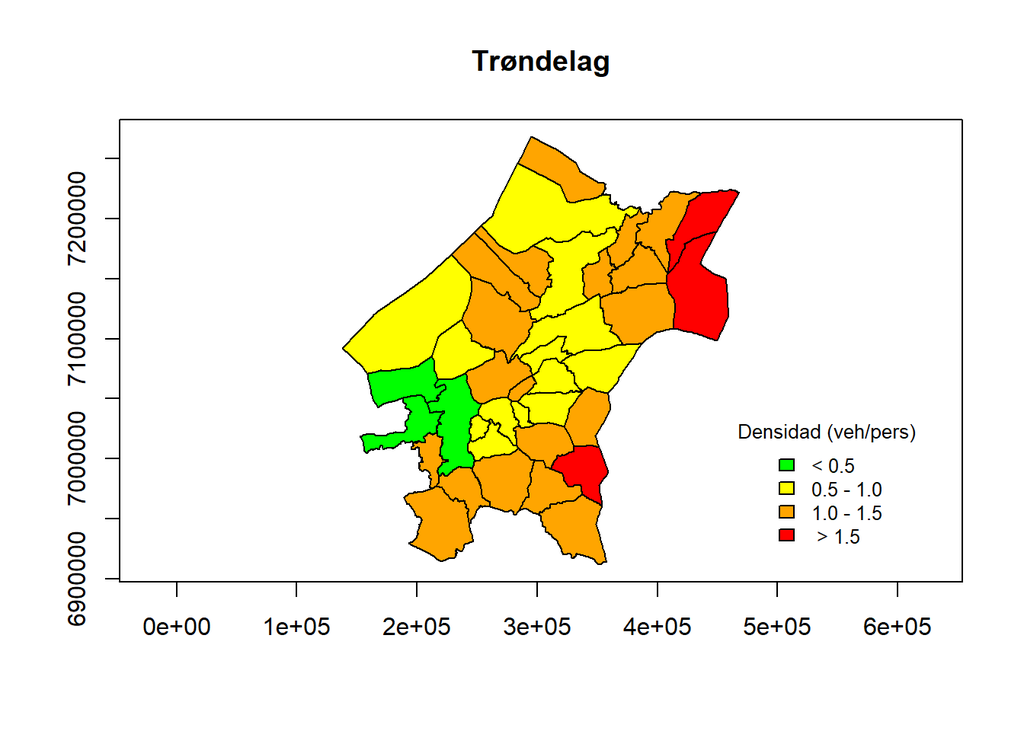

```r
KjpcInn <- subset(Kj_K_V, Fylke == "Trøndelag - Trööndelage")


plot (KjpcInn,
      col = c("green","yellow","orange","red")[KjpcInn$kjpc_f],
      axes=TRUE, main = "Trøndelag")
legend ("bottomright", inset=.05,title = expression("Densidad (veh/pers)"), legend = c("< 0.5","0.5 - 1.0","1.0 - 1.5", " > 1.5" ), fill = c("green","yellow","orange","red"), KjpcInn$kjpc_f, cex=0.8, box.col = NA)
```

Por tipo de vehiculos: Beltemotorsykler

En finnmark motonieves

```r
kj_BM_K <- datosV %>% filter (kjøretøy == "Beltemotorsykler") %>%    group_by(Kom, kommunenum, Fylke, Befolkning_2020) %>% summarize (total_bm = sum(tall))
```

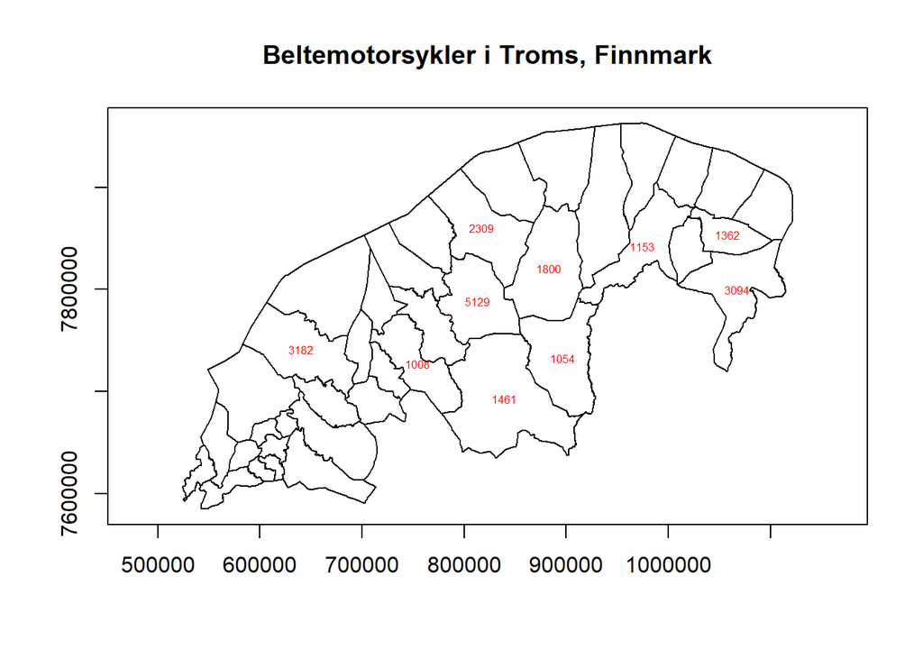

```r
Kj_BM_K_V <- merge (kommunerV,
                 kj_BM_K,
                 by="kommunenum")


BM_TFN <- subset(Kj_BM_K_V, Fylke == "Troms og Finnmark - Romsa ja Finnmárku - Tromssa ja Finmarkku")

BM_TFN1000 <- subset(Kj_BM_K_V, Fylke == "Troms og Finnmark - Romsa ja Finnmárku - Tromssa ja Finmarkku" & total_bm > 1000)

plot(BM_TFN, axes = TRUE, main = "Beltemotorsykler i Troms, Finnmark")
text(BM_TFN1000, BM_TFN1000$total_bm, col = "red", cex = 0.5)
```

Por tipos de vehiculos: traktorer

Tractores en Troms y Finnmark

```r
kj_Trak_K <- datosV %>% filter (kjøretøy == "Traktorer") %>%    group_by(Kom, kommunenum, Fylke, Befolkning_2020) %>% summarize (total_tr = sum(tall))
```

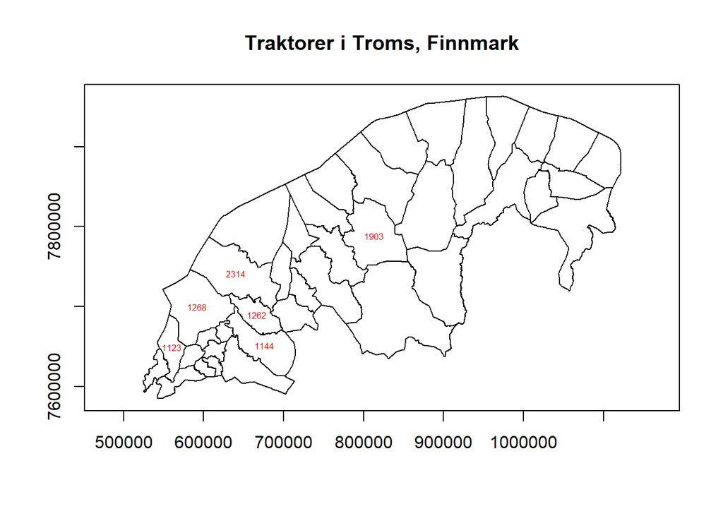

```r
Kj_Trak_K_V <- merge (kommunerV,
                 kj_Trak_K,
                 by="kommunenum")


TR_TFN <- subset(Kj_Trak_K_V, Fylke == "Troms og Finnmark - Romsa ja Finnmárku - Tromssa ja Finmarkku")

TR_TFN1000 <- subset(Kj_Trak_K_V, Fylke == "Troms og Finnmark - Romsa ja Finnmárku - Tromssa ja Finmarkku" & total_tr > 1000)

plot(TR_TFN, axes = TRUE, main = "Traktorer i Troms, Finnmark")
text(TR_TFN1000, TR_TFN1000$total_tr, col = "red", cex = 0.5)
```